사용데이터 : https://2stndard.tistory.com/68

앞선 포스트(https://2stndard.tistory.com/75)에서는 백분률을 사용한 히스토그램을 어떻게 그리는지 살펴보았다. 하지만 이 포스트에서 만들어낸 결과는 두가지 점에서 바로 사용하기가 좀 어려울 것이다.

첫 번째는 막대로 백분률을 표시는 했지만 그 정확한 값을 알수가 없다는 것이다. 막대간의 비교는 가능해 어떤 변수값이 가장 많이 분포하는 지는 알수 있지만 이는 빈도수로 표현된 히스토그램으로도 알수 있다. 따라서 정확한 백분률을 표시해 주는 것이 효과적일 것이다.

두 번째는 막대 그래프는 오름차순이나 내림차순으로 막대를 배치할 때 그 활용도가 커진다. 하지만 앞선 포스팅에서 그려진 막대 그래프의 막대는 들쭉 날쭉하다.

이를 다음과 같이 해결해 보겠다.

## 백분률의 표시

앞선 포스트에서 그렸던 연속형 변수에 대한 백분률 히스토그램과 이산형 변수에 대한 백분률 히스토그램에 백분률을 표현하는 방법을 구분하였고 이에 따라 사용하는 함수도 `geom_histogram()`과 `geom_bar()`로 구분하여 생성하였다. 백분률의 표시도 이 두 함수의 사용에 따라 달라진다.

먼저 `geom_histogram()`에서 백분률을 표시하기 위해서는 `stat_bin()`를 사용하여야 한다. `stat_bin()`는 히스토그램을 표현하는데 중요하게 사용되는 binning에 따른 기하요소의 사용을 위한 함수이다. `ggplot2`에서 데이터 값을 표현하는데 가장 흔하게 사용되는 `geom_text()`는 binning을 사용하기가 어렵기 때문에 `stat_bin()`를 사용하여야 한다.

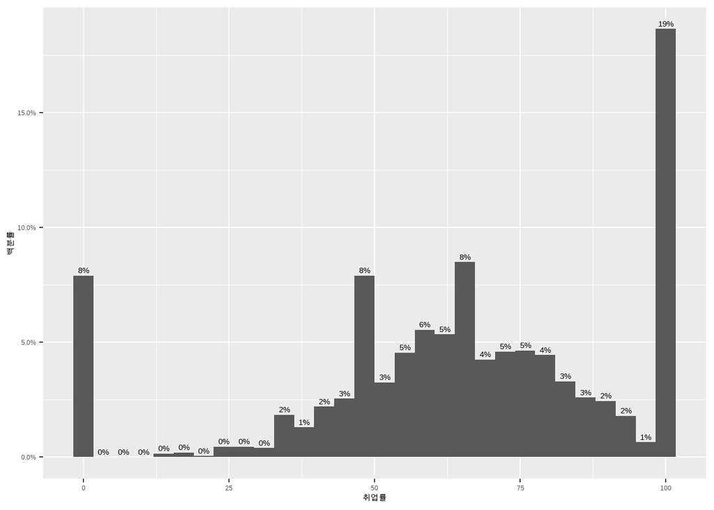

```r
df_취업률_2000 |>
  ggplot() +
  geom_histogram(aes(x = 취업률, y = ..count../sum(..count..))) +
  stat_bin(aes(x = 취업률, y = ..count../sum(..count..),
               label = scales::percent(..count../sum(..count..), accuracy = 1)),
           geom = 'text', vjust = -0.5) +
  scale_y_continuous(labels = scales::percent) +
  labs(y = '백분률')
```

binning을 `binwidth`로 설정한 경우는 다음과 같이 `stat_bin()`에 `binwidth`를 설정해 줌으로써 히스토그램을 만들수 있다.

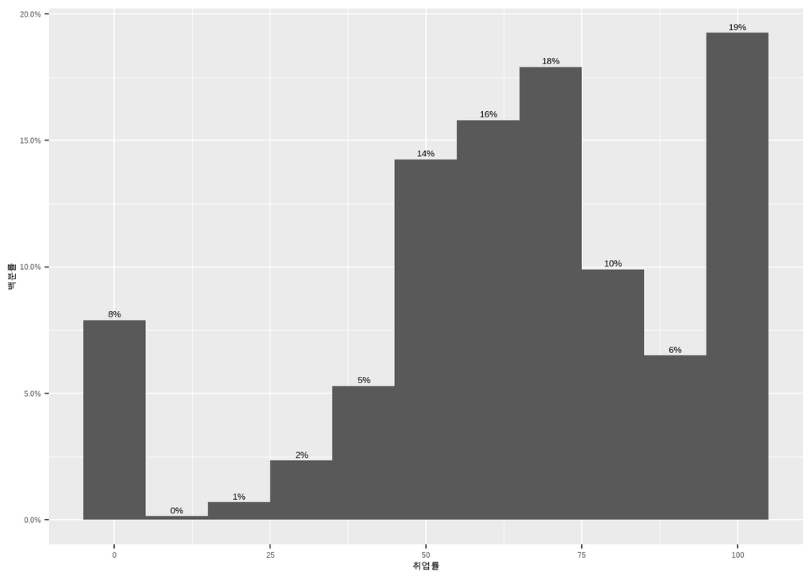

```r
df_취업률_2000 |>
  ggplot() +
  geom_histogram(aes(x = 취업률, y = ..count../sum(..count..)), binwidth = 10) +
  stat_bin(aes(x = 취업률, y = ..count../sum(..count..),
               label = scales::percent(..count../sum(..count..), accuracy = 1)),
           geom = 'text', vjust = -0.5,
           binwidth = 10) +
  scale_y_continuous(labels = scales::percent) +
  labs(y = '백분률')
```

이산형 변수에 대한 히스토그램을 그리는데 사용한 `geom_bar()`는 `geom_text()`를 사용함으로써 백분률을 표시할 수 있다. 이번에는 비율과 개수를 같이 표현해보도록 하겠다.

이산형 변수에 대한 히스토그램을 그리는 방법으로 `..count..` 사용, `after_stat()`의 사용, `..prop..`의 사용 세 가지 방법으로 설명하였는데 각각의 방법에 따라 백분률을 표현하는 방법은 다음과 같다.

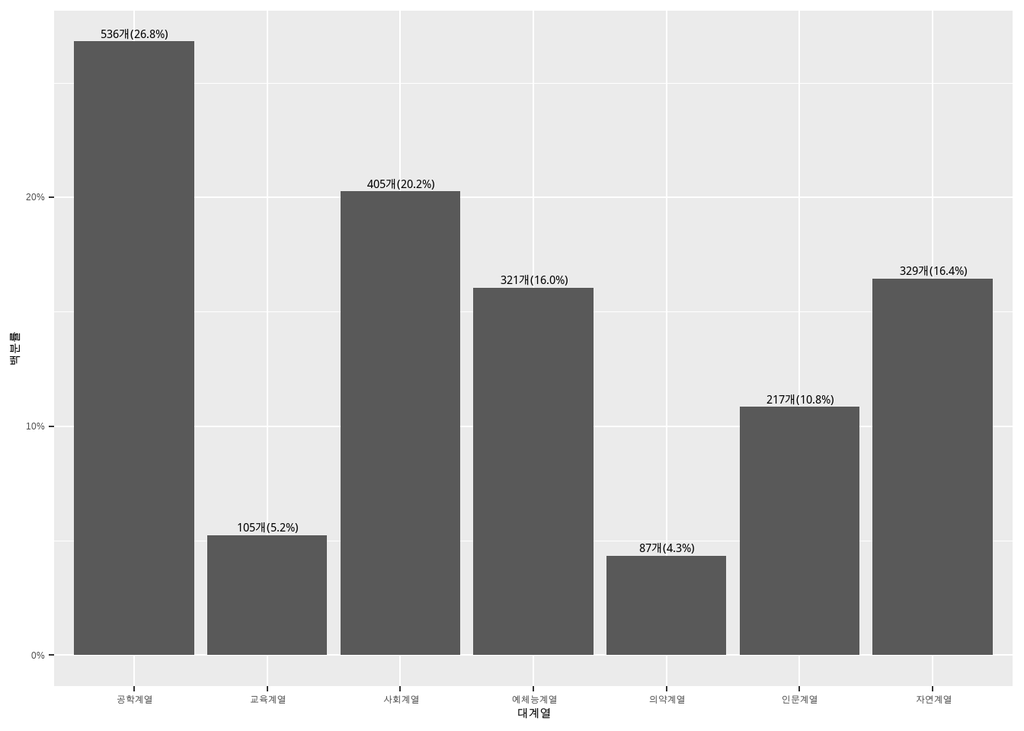

```r
## ..count..를 사용하는 방법
df_취업률_2000 |>
  ggplot() +
  geom_bar(aes(x = 대계열, y = ..count../sum(..count..))) +
  geom_text(aes(x = 대계열, y = ..count../sum(..count..), group = 1,
                label = paste0(..count.., '개(', scales::percent(..prop.., accuracy = 0.1), ')')
                ),
            stat = 'count', vjust = -0.5
            ) +
  scale_y_continuous(labels = scales::percent) +
  labs(y = '백분률')
```

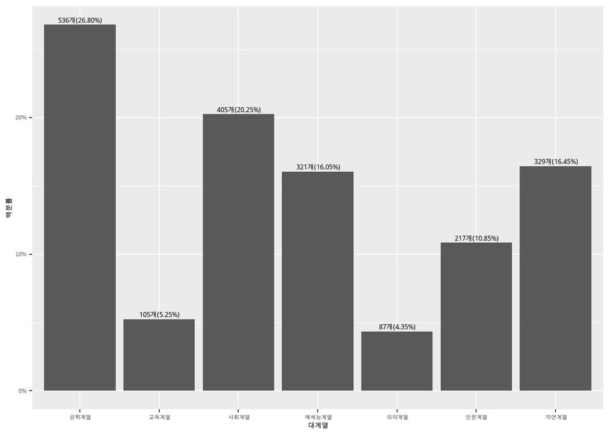

```r
## after_stat()을 사용한 방법
df_취업률_2000 |>
  ggplot(aes(x = 대계열, y = after_stat(count/sum(count)))) +
  geom_bar() +
  geom_text(aes(label = paste0(after_stat(count), '개(', scales::percent(after_stat(count/sum(count))), ')')
                ),
            stat= "count", vjust = -0.5) +
  scale_y_continuous(labels = scales::percent) +
  labs(y = '백분률')
```

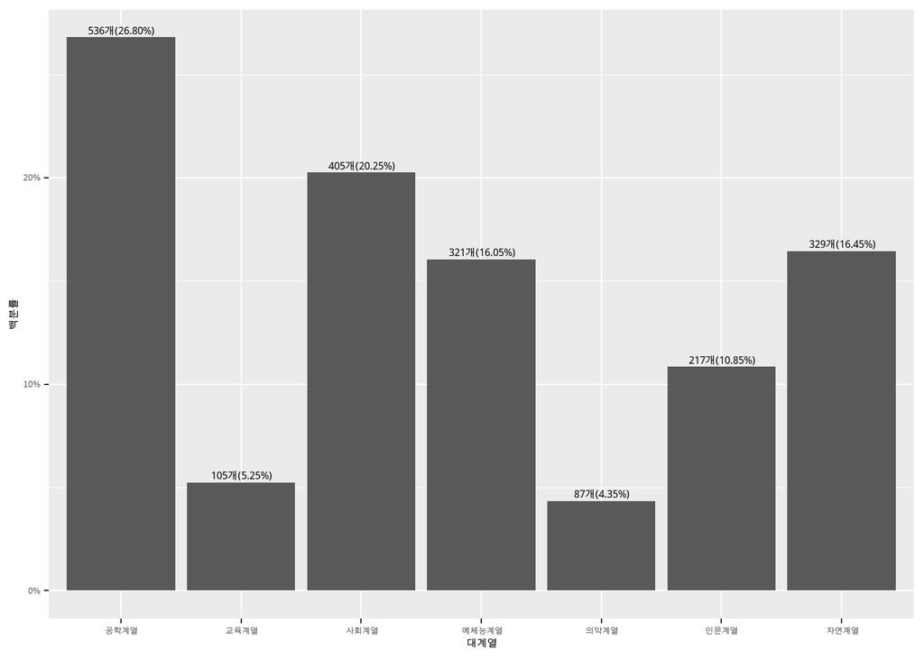

```r
## ..prop..을 사용한 방법
df_취업률_2000 |>
  ggplot() +
  geom_bar(aes(x = 대계열, y = ..prop.., group = 1)) +
  geom_text(aes(x = 대계열, y = ..prop.., group = 1,
                label = paste0(..count.., '개(', scales::percent(..prop..), ')')
                ),
            stat= "count", vjust = -0.5) +
  scale_y_continuous(labels = scales::percent) +
  labs(y = '백분률')
```

## 데이터 막대 정렬

앞서 본 막대 그래프들은 모두 막대가 그 값에 관계없이 가나다 순으로 정렬되어 있다. 막대 그래프는 데이터간의 비교를 위해 많이 사용되는데 이런 정렬은 데이터간 비교에 다소 무리가 따른다. 예를 들어 세번째로 데이터가 많은 항목을 찾아라라고 한다면 사용자가 스스로 세 번째 데이터를 찾아야한다. 따라서 데이터 값의 순서로 막대를 정렬하면 더 비교가 편하게 될 것이다.

다만 이렇게 막대를 정렬해야하는 경우는 연속형 변수의 히스토그램은 사용할 수 없다. 연속형 변수에 대한 히스토그램은 막대의 구간이 순차적으로 정해지기 때문에 정렬이 큰 의미가 없기 때문이다.

이산형 히스토그램에 사용한 세가지 방법 모두 `forcats::fct_infreq()`를 사용하면 정렬이 가능하다. `forcats::fct_infreq()`은 매개변수로 전달하는 벡터를 팩터로 변환하고 그 빈도에 따라 레벨의 순서(order)를 설정해주는 함수이다.

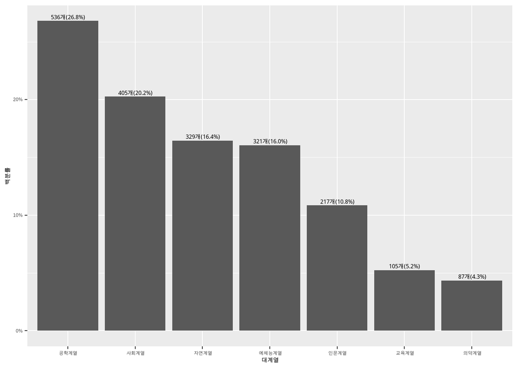

```r
## ..count..를 사용하는 방법
df_취업률_2000 |>
  ggplot() +
  geom_bar(aes(x = forcats::fct_infreq(대계열), y = ..count../sum(..count..))) +
  geom_text(aes(x = forcats::fct_infreq(대계열), y = ..count../sum(..count..), group = 1,
                label = paste0(..count.., '개(', scales::percent(..prop.., accuracy = 0.1), ')')
                ),
            stat = 'count', vjust = -0.5
            ) +
  scale_y_continuous(labels = scales::percent) +
  labs(x = '대계열', y = '백분률')
```

```r
## after_stat()을 사용한 방법
df_취업률_2000 |>
  ggplot(aes(x = forcats::fct_infreq(대계열), y = after_stat(count/sum(count)))) +
  geom_bar() +
  geom_text(aes(label = paste0(after_stat(count), '개(', scales::percent(after_stat(count/sum(count))), ')')
                ),
            stat= "count", vjust = -0.5) +
  scale_y_continuous(labels = scales::percent) +
  labs(x = '대계열', y = '백분률')
```

```r
## ..prop..을 사용한 방법
df_취업률_2000 |>
  ggplot() +
  geom_bar(aes(x = forcats::fct_infreq(대계열), y = ..prop.., group = 1)) +
  geom_text(aes(x = forcats::fct_infreq(대계열), y = ..prop.., group = 1,
                label = paste0(..count.., '개(', scales::percent(..prop..), ')')
                ),
            stat= "count", vjust = -0.5) +
  scale_y_continuous(labels = scales::percent) +
  labs(x = '대계열', y = '백분률')
```

위와 같이 특수한 함수를 사용하는 경우는 다소 어려운 방법임에 틀림없다. 일반적인 사용자라면 `dplyr`를 사용하여 빈도와 비율을 구하도록 전처리하고 이 결과로 시각화하는 방법을 선호할 것이다. 어쩌면 이 방법이 더 효율적일수도 있을 것이다.

먼저 데이터 전처리를 해야하는데 `group_by()`를 사용하여 변량별로 그룹화하고 이 그룹별로 사례수와 비율을 구하는 열을 추가해준다. 여기서 `summarise()`와 `mutate()`를 따로 사용하였는데 그 이유는 이전 포스트(https://2stndard.tistory.com/56)를 참조하라.

```r
df_취업률_2000 |>
  group_by(대계열) |>
  summarise(n = n()) |>
  mutate(rate = n/sum(n))
```

```
## # A tibble: 7 x 3
##   대계열         n   rate
##   <chr>      <int>  <dbl>
## 1 공학계열     536 0.268
## 2 교육계열     105 0.0525
## 3 사회계열     405 0.202
## 4 예체능계열   321 0.160
## 5 의약계열      87 0.0435
## 6 인문계열     217 0.108
## 7 자연계열     329 0.164
```

그리고 정렬을 위해서는 앞서 사용한 `forcats::fct_infreq(대계열)`을 사용할 수도 있지만 `reorder()`를 사용하였다. 하나 주의해야하는 것이 `geom_bar()`의 `stat`을 앞서 사용했던 ‘count’를 사용하지 않고 ’identity’를 사용했다는 것이다. 앞서 사용했던 방법들은 `geom_bar()`에서 사례수를 카운트하는 통계처리가 필요하기 때문에 `stat`을 ’count’ 로 설정했지만 미리 전처리되어 추가적인 통계처리가 필요하지 않고 수치 자체를 사용하기 때문에 그 수치를 통계변환하지 않고 자체로 사용하는 의미인 ’identity’를 설정하였다.

```r
df_취업률_2000 |>
  group_by(대계열) |>
  summarise(n = n()) |>
  mutate(rate = n/sum(n)) |>
  ggplot() +
  geom_bar(aes(x = reorder(대계열, n, desc), y = rate), stat = 'identity') +
  geom_text(aes(x = reorder(대계열, n, desc), y = rate, label = paste0(n, '개(', scales::percent(rate), ')')), vjust = -0.5) +
  scale_y_continuous(labels = scales::percent) +
  labs(x = '대계열', y = '백분률')
```